[figure not shown]

Измерение и тестирование

пропускной способности сети

Лабораторная работа № 2

Студент:Авдадаев Джамал Геланиевич

Российский университет дружбы народов, Москва, Россия

26 сентября 2026

[figure not shown]

Цели и задачи работы

2/18

Цель работы: познакомиться с

инструментом iPerf3 для

измерения пропускной

способности сети в режиме

реального времени, провести

интерактивные

эксперименты в Mininet и

построить графики по

результатам измерений.

Задача работы

• научиться измерять пропускную

способность моделируемой сети в

реальном времени;

• получить практику запуска клиент-

серверных тестов iPerf3;

• сравнить режимы TCP, UDP и

дополнительные параметры запуска;

• сформировать данные JSON и построить

графики результата.

Результат: набор тестов, JSON-файл и PDF-

графики throughput, cwnd, RTT, retransmits,

MTU и bytes.

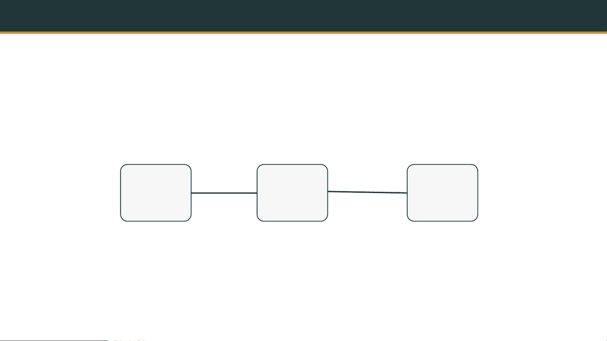

Объект, предмет и инструменты

4/18

• Объект исследования: моделируемая сеть Mininet из двух хостов и

коммутатора.

• Предмет исследования: пропускная способность, jitter, потери

датаграмм, повторные передачи TCP.

• Инструменты: Ubuntu Mininet VM, PuTTY, XLaunch, iPerf3, jq, gnuplot,

evince, iperf3_plotter.

h1

10.0.0.1 s1 h2

10.0.0.2

iperf3: клиент → сервер

Базовая схема эксперимента: h1 выступает клиентом, h2 — сервером

iPerf3.

[figure not shown]

Ход выполнения работы

5/18

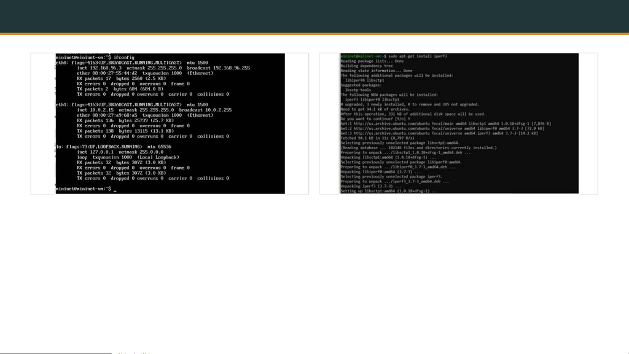

Подготовка среды и установка ПО

6/18

Проверка интерфейсов VM: eth0 и eth1 Установка iPerf3 и зависимостей

На виртуальной машине проверены сетевые интерфейсы, обновлены репозитории и установлен iPerf3. Дополнительно

установлены git, jq, gnuplot-nox и evince для обработки и визуализации данных.

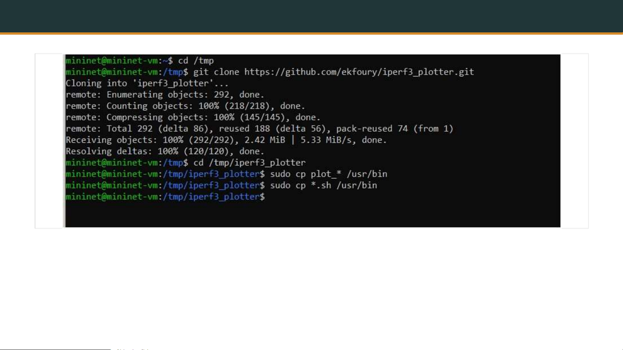

Развёртывание iperf3_plotter

7/18

Репозиторий iperf3_plotter был склонирован во временный каталог, после чего скрипты были скопированы в /usr/bin. Для

совместимости с методичкой использованы legacy-скрипты plot_iperf.sh и preprocessor.sh.

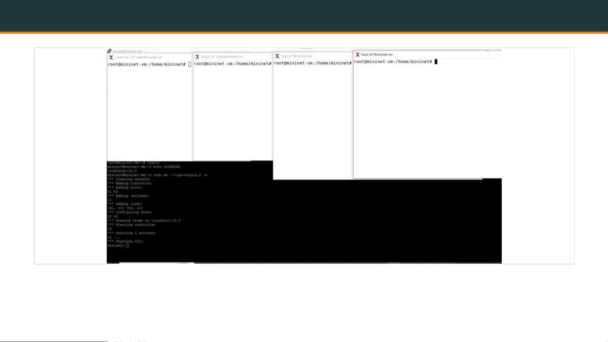

Запуск топологии Mininet

8/18

Запуск topology single,2 с XTerm-окнами h1, h2, s1 и c0

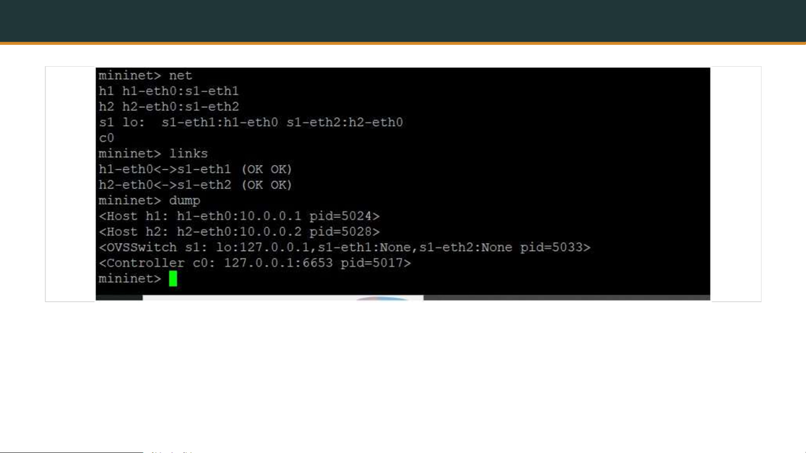

Проверка топологии

9/18

• h1 получил адрес 10.0.0.1;

• h2 получил адрес 10.0.0.2;

• оба канала h1–s1 и h2–s1 находятся в состоянии OK.

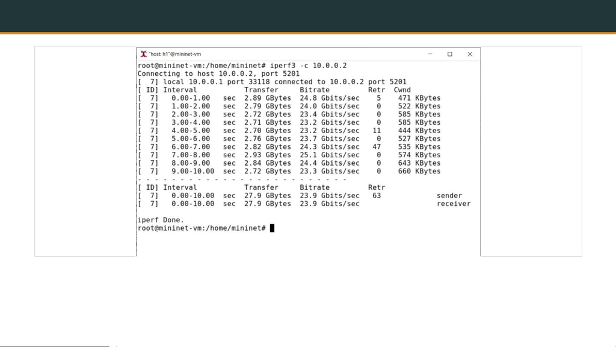

Базовый TCP-тест в отдельных терминалах

10/18

Результат: 27.9 GBytes за 10 секунд, средняя скорость 23.9 Gbit/s, Retr = 63.

Клиент h1 подключается к серверу iPerf3 на h2 по адресу 10.0.0.2:5201

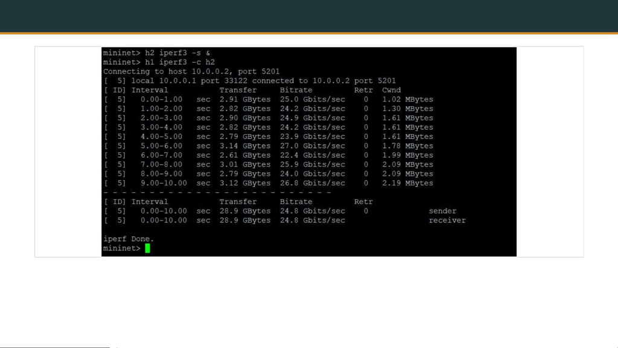

Эксперимент через CLI Mininet

11/18

Результат: 28.9 GBytes за 10 секунд, средняя скорость 24.8 Gbit/s, Retr = 0.

Команды h2 iperf3 -s & и h1 iperf3 -c h2 выполнены из приглашения mininet>

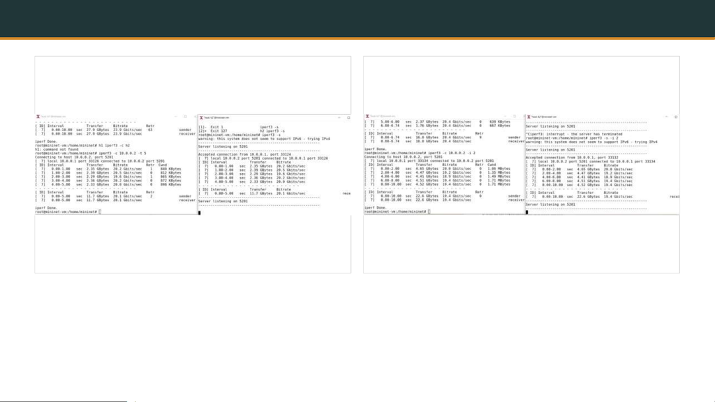

Управление длительностью и интервалом отчёта

12/18

Опция -t 5: тест длится 5 секунд Опция -i 2: отчёт выводится каждые 2 секунды

Итоги: при -t 5 передано 11.7 GBytes со скоростью 20.1 Gbit/s; при -i 2 передано 22.6 GBytes со скоростью 19.4 Gbit/s.

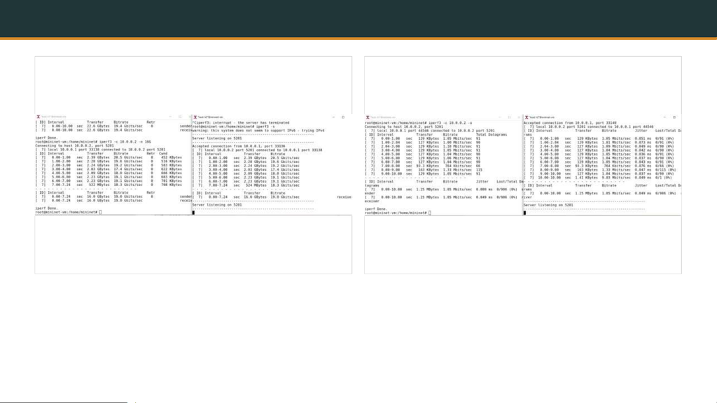

Фиксированный объём и UDP

13/18

Опция -n 16G: передача заданного объёма данных Опция -u: UDP, jitter и потери датаграмм

TCP -n 16G: 16.0 GBytes за 7.24 секунды, 19.0 Gbit/s. UDP: 1.25 MBytes, 1.05 Mbit/s, jitter ≈ 0.049 ms, потери 0/906.

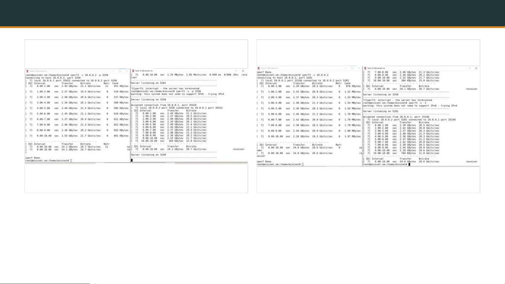

Порт 3250 и режим одного клиента

14/18

Передача через нестандартный порт 3250 Опция -1: сервер завершает работу после одного клиента

Проверены дополнительные режимы сервера iPerf3: смена порта через -p и автоматическая остановка сервера после одного

клиентского подключения через -1.

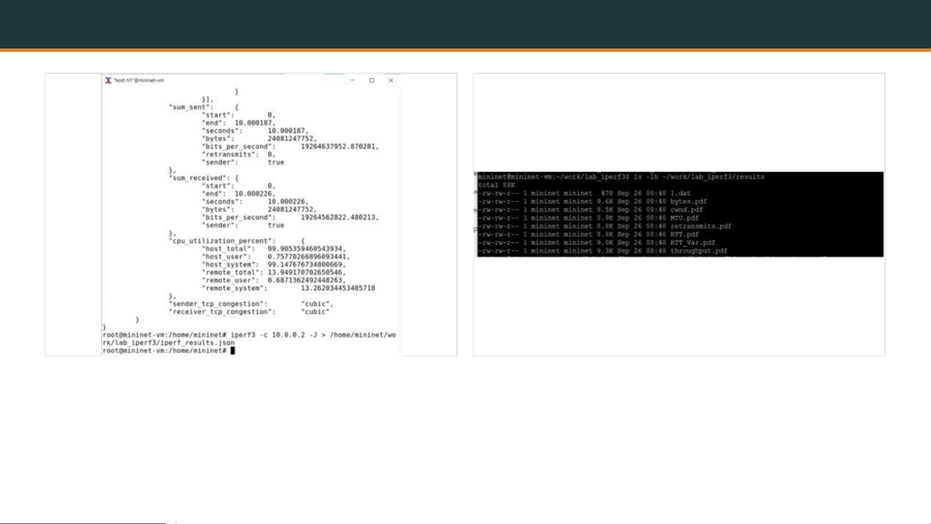

Экспорт JSON и построение графиков

15/18

Экспорт результата iPerf3 в JSON Сформированы файлы 1.dat и PDF-графики

Вывод в формате JSON был сохранён в iperf_results.json. На основе файла сгенерированы графики throughput, cwnd, retransmits,

RTT, RTT_Var, MTU и bytes.

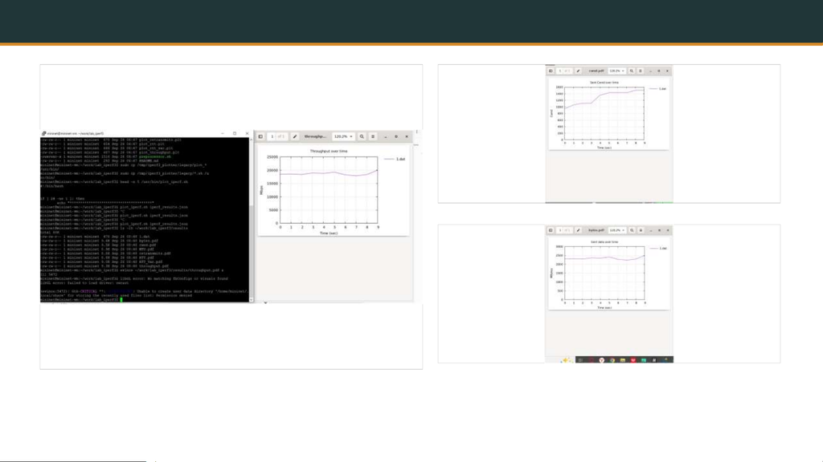

Визуализация результатов

16/18

Основной график throughput показывает устойчивый уровень около 18–20 Gbit/s.

[figure not shown]

Выводы

17/18

[figure not shown]

Итог лабораторной работы

18/18

• установлены iPerf3 и вспомогательные пакеты для обработки результатов;

• в Mininet запущена топология h1—s1—h2 с адресами 10.0.0.1 и 10.0.0.2;

• проведены TCP-тесты в отдельных терминалах и через интерфейс Mininet;

• проверены параметры -t, -i, -n, -u, -p и -1;

• результаты экспортированы в JSON и преобразованы в графики;

• основной график throughput подтвердил стабильную пропускную способность порядка 18–20 Gbit/s.